# Summary of the current season

### This season

| Team | Win | Tie | Loss | Games |
| --- | --- | --- | --- | --- |
| Arbornauts | 6 | 0 | 0 | 6 |
| Bottom Of The Fifths | 5 | 0 | 1 | 6 |
| Not Here To Make Friends | 4 | 0 | 2 | 6 |
| Seattle Shaggy Muskrats | 3 | 0 | 2 | 5 |
| Balls Deep | 3 | 0 | 3 | 6 |
| Hitmen | 3 | 0 | 3 | 6 |
| Seattle Seattle Mariners | 3 | 0 | 3 | 6 |
| The Crows | 3 | 0 | 3 | 6 |
| We Love Dishwashers | 3 | 0 | 3 | 6 |
| Stranger Danger | 2 | 0 | 3 | 5 |
| Eagle Bait | 2 | 0 | 4 | 6 |
| Flesh Eating Sharks | 1 | 0 | 5 | 6 |
| Suicide Squeeze Squad | 0 | 0 | 6 | 6 |

This table shows the outcome of the non-forfeited games played this season (Fall 2017). Forfeits are not included because they don’t reflect skill.

| Team | Scored | Allowed | Margin |
| --- | --- | --- | --- |
| Bottom Of The Fifths | 21 | 10.3 | 10.7 |
| Arbornauts | 18.5 | 8.5 | 10 |
| Seattle Shaggy Muskrats | 16.4 | 9.8 | 6.6 |
| Balls Deep | 13.7 | 10.7 | 3 |
| We Love Dishwashers | 18 | 15.5 | 2.5 |
| Not Here To Make Friends | 16.2 | 14 | 2.2 |
| Eagle Bait | 13.8 | 12.3 | 1.5 |
| Seattle Seattle Mariners | 11.3 | 11.3 | 0 |
| Stranger Danger | 12.4 | 15.8 | -3.4 |
| The Crows | 10.5 | 15.7 | -5.2 |
| Hitmen | 12.7 | 18.2 | -5.5 |
| Flesh Eating Sharks | 15 | 23 | -8 |
| Suicide Squeeze Squad | 7 | 20.8 | -13.8 |

This table shows the average number of runs scored and allowed from this seasons, as well as the average margin (the difference between the number of runs scored and allowed).

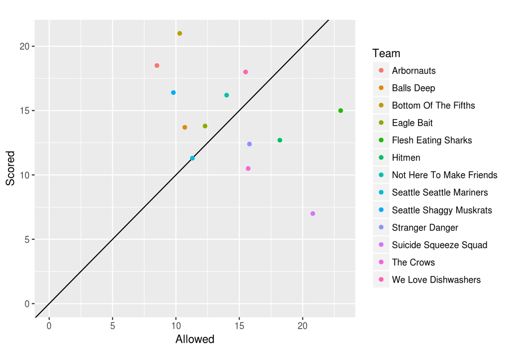

This figure shows the relationship between the average number of runs a team scores and the number they allow. Points along the black line represent teams that, on average, score an equal number of runs to the number they allow. Teams above the line score more than they allow and below the line score fewer than they allow.

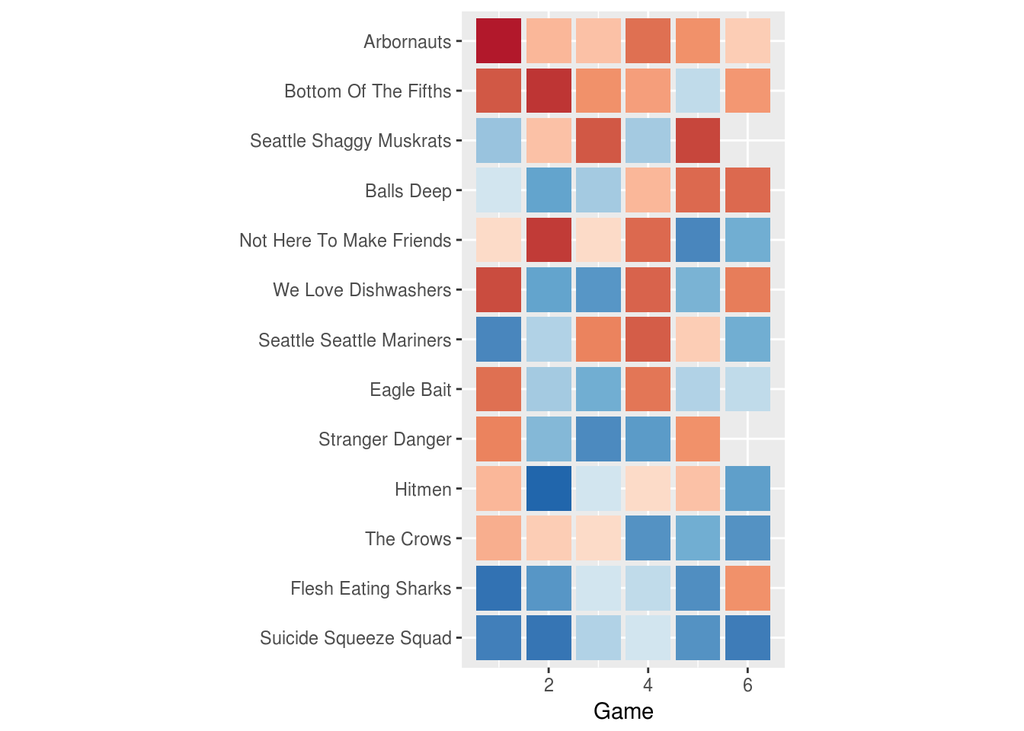

This figure shows the outcomes of all non-forfeited games from this season. Each square represents a game and color represents the difference between what the scores, where red represents a win and blue represents a loss, with darker red meaning a bigger blowout.

### All time statistics

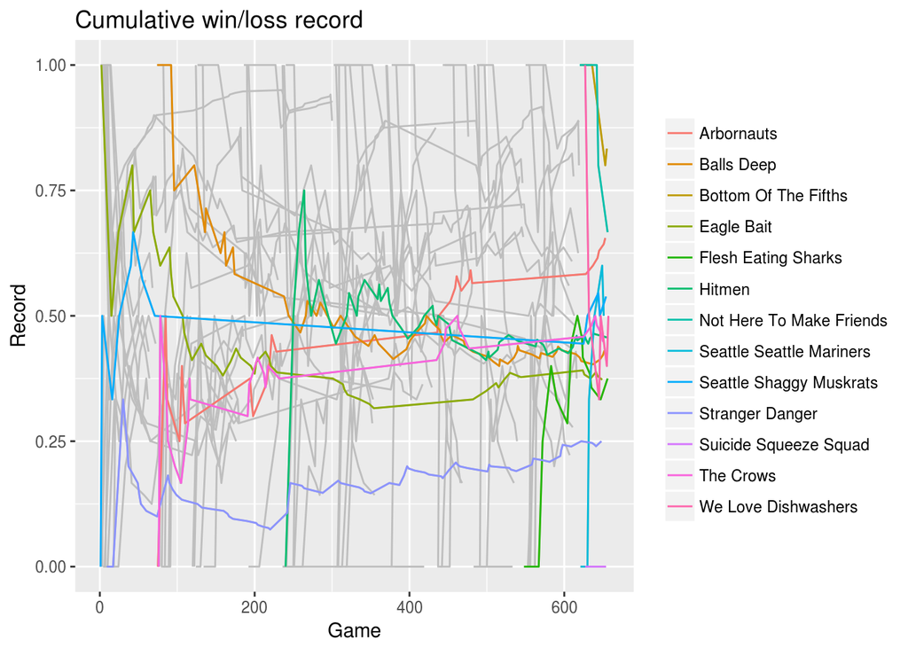

This figure shows the cumulative win/loss record for all teams, with the teams playing this season highlighted. Games are numbered sequentially starting from the first game of Stranger Danger’s first season (summer 2013!). Stranger Danger continues its steady recovery from the painful early seasons.

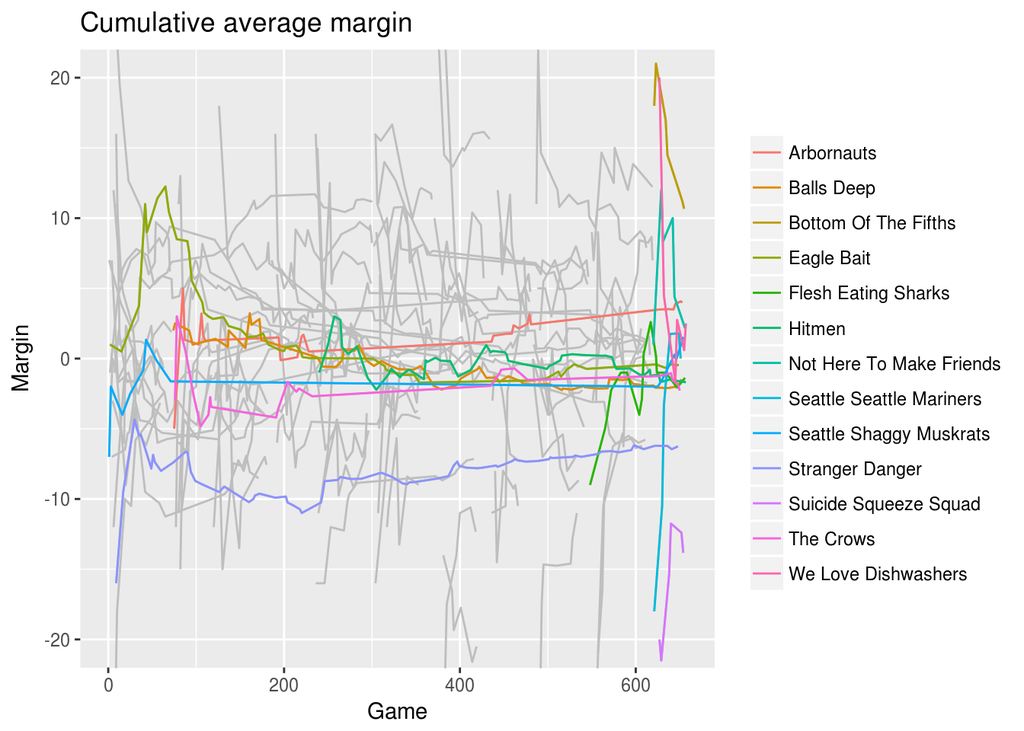

This figure shows the cumulative average score margin for all teams, with the teams playing this season highlighted. Stranger Danger continues its steady recovery from the painful early seasons.